# Vad är en DNA-barcode-visualisering?

## En DNA streckkodsekvens från en blåkråka

```
CTAATTTTTGGGGCCTGAGCGGGCATGGTTGGAACCGCCCTCAGCCTGCTCATTCGCGCAGAA
CTCGGTCAACCAGGAACCCTACTAGGAGACGACCAGATCTACAACGTAATCGTCACTGCCCAT
GCCTTCGTAATAATCTTCTTTATAGTCATACCAATCATAATCGGGGGCTTTGGAAACTGACTA
GTCCCCCTTATAATCGGCGCCCCAGACATAGCGTTCCCCCGTATAAATAACATAAGCTTCTGA
CTACTCCCCCCATCCTTCCTTCTCCTACTAGCCTCCTCCACCGTAGAAGCTGGTGCTGGTACA
GGGTGAACAGTCTACCCCCCTCTAGCTGGTAATCTGGCCCACGCCGGAGCTTCTGTAGACCTA
GCCATCTTCTCCCTACACCTCGCTGGAGTCTCATCAATCCTAGGTGCAATCAACTTCATCACT
ACTGCCATTAACATAAAGCCCCCGGCCCTATCTCAATACCAAACCCCCCTATTCGTATGATCC
GTACTAATCACAGCCGTCCTACTATTACTTTCACTGCCCGTCCTCGCTGCCGGCATTACAATG
CTCCTCACAGACCGAAACCTAAACACCACATTCTTTGACCCAGCCGGAGGAGGAGACCCAGTC
CTATACCAACACCTATTC
```

## En DNA streckkodsekvens från en morkulla

```
CTAATCTTCGGTGCATGAGCTGGCATGGTCGGAACCGCCCTCAGCCTGCTTATTCGTGCAGAA
CTAGGCCAACCAGGAACCCTCTTGGGAGATGACCAAATCTACAATGTAATCGTTACTGCTCAT
GCATTCGTAATAATTTTCTTCATAGTTATACCAATCATGATCGGAGGATTTGGAAATTGACTA
GTCCCACTCATAATCGGCGCCCCCGACATAGCATTTCCTCGTATAAACAATATAAGCTTCTGA
CTACTCCCCCCATCATTCCTATTATTACTAGCATCCTCTACAGTAGAAGCTGGAGCTGGCACA
GGATGAACAGTATATCCACCCCTCGCCGGCAACCTAGCCCACGCAGGAGCCTCAGTAGACCTA
GCTATTTTCTCCCTCCATTTAGCAGGTGTCTCCTCCATCCTAGGTGCCATTAACTTTATCACC
ACTGCCATTAACATAAAACCACCAGCCCTGTCCCAATACCAAACACCCCTATTTGTATGATCA
GTACTCATTACCGCCGTCTTACTGCTACTCTCACTCCCAGTCCTTGCTGCCGGCATCACCATG
CTATTAACAGATCGTAATCTAAACACCACATTCTTTGACCCAGCCGGAGGAGGAGACCCAGTC
CTATACCAACATCTCTTC
```

## Referensexemplar

Referensexemplaren som finns bevarade på Naturhistoriska Riksmuseet av blåkråka (Cat. id. NRM 20106015) - den övre bilden - och morkulla (Cat. id. NRM 20046331) - den nedre bilden - som de illustrerade streckkoderna har sekvenserats ifrån.

I detta fall en felflugen blåkråka från Ramsberg norr om Lindesberg.

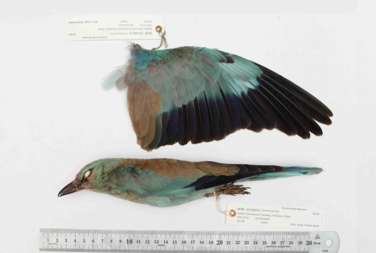

Och en morkulla från Fibysjön utanför Uppsala.

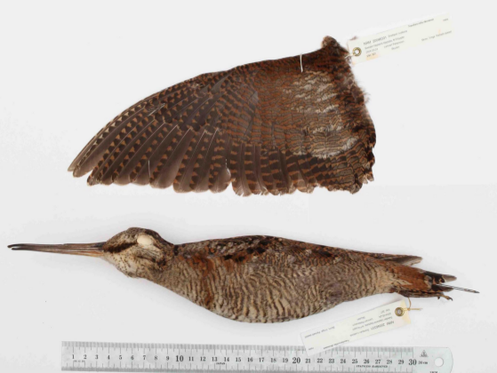

## Visualisering

Man kan visualisera en DNA sekvens på ett sätt som blir mer överskådligt om man låter linjer i fyra olika färger representera ordningen av kvävebaserna A, C, T och G i genen.

Samma sak illustrerat med radbruten färgkodning:

```
███████████████████████████████████████████████████████████████
███████████████████████████████████████████████████████████████
███████████████████████████████████████████████████████████████
███████████████████████████████████████████████████████████████
███████████████████████████████████████████████████████████████
███████████████████████████████████████████████████████████████
███████████████████████████████████████████████████████████████
███████████████████████████████████████████████████████████████
███████████████████████████████████████████████████████████████
███████████████████████████████████████████████████████████████
██████████████████
```

```
███████████████████████████████████████████████████████████████
███████████████████████████████████████████████████████████████
███████████████████████████████████████████████████████████████
███████████████████████████████████████████████████████████████
███████████████████████████████████████████████████████████████
███████████████████████████████████████████████████████████████
███████████████████████████████████████████████████████████████
███████████████████████████████████████████████████████████████
███████████████████████████████████████████████████████████████
███████████████████████████████████████████████████████████████
██████████████████
```

## Jämförelse - var skiljer sig sekvenserna åt?

Horisontell sektionsvis jämförelse av enbart 3.e kodon - dvs begränsat urval till tecken i positioner jämnt delbara med tre:

```
███████████████████████████████████████████████████████████████
███████████████████████████████████████████████████████████████
███████████████████████████████████████████████████████████████
███████████████████████████
```

```
███████████████████████████████████████████████████████████████
███████████████████████████████████████████████████████████████
███████████████████████████████████████████████████████████████
███████████████████████████
```

Radvis jämförelse med skillnader framhävda med grå markering:

```
███████████████████████████████████████████████████████████████
███████████████████████████████████████████████████████████████
███████████████████████████████████████████████████████████████

███████████████████████████████████████████████████████████████
███████████████████████████████████████████████████████████████
███████████████████████████████████████████████████████████████

███████████████████████████████████████████████████████████████
███████████████████████████████████████████████████████████████
███████████████████████████████████████████████████████████████

███████████████████████████
███████████████████████████
███████████████████████████
```

Illustrerade som separata stycken, färgkodade och radbrutna:

```
███████████████████████████████████████████████████████████████
███████████████████████████████████████████████████████████████
███████████████████████████████████████████████████████████████
███████████████████████████████████████████████████████████████
███████████████████████████████████████████████████████████████
███████████████████████████████████████████████████████████████
██████████████████████████████████████████████████████
```

```
███████████████████████████████████████████████████████████████
███████████████████████████████████████████████████████████████
███████████████████████████████████████████████████████████████
███████████████████████████████████████████████████████████████
███████████████████████████████████████████████████████████████
███████████████████████████████████████████████████████████████
██████████████████████████████████████████████████████
```

Jämförelsevisualisering - för detta urval av data ser vi betydligt färre skillnader:

```
███████████████████████████████████████████████████████████████
███████████████████████████████████████████████████████████████
███████████████████████████████████████████████████████████████

███████████████████████████████████████████████████████████████
███████████████████████████████████████████████████████████████
███████████████████████████████████████████████████████████████

███████████████████████████████████████████████████████████████
███████████████████████████████████████████████████████████████
███████████████████████████████████████████████████████████████

███████████████████████████████████████████████████████████████
███████████████████████████████████████████████████████████████
███████████████████████████████████████████████████████████████

███████████████████████████████████████████████████████████████
███████████████████████████████████████████████████████████████
███████████████████████████████████████████████████████████████

███████████████████████████████████████████████████████████████
███████████████████████████████████████████████████████████████
███████████████████████████████████████████████████████████████

██████████████████████████████████████████████████████
██████████████████████████████████████████████████████
██████████████████████████████████████████████████████
```

Och om vi slutligen gör samma sak för kodon-3-dataurvalet, men dessutom lyfter fram skillnaderna ytterligare, såsom ovan, genom att tona ned likheterna:

```
███████████████████████████████████████████████████████████████
███████████████████████████████████████████████████████████████
███████████████████████████████████████████████████████████████

███████████████████████████████████████████████████████████████
███████████████████████████████████████████████████████████████
███████████████████████████████████████████████████████████████

███████████████████████████████████████████████████████████████
███████████████████████████████████████████████████████████████
███████████████████████████████████████████████████████████████

███████████████████████████
███████████████████████████
███████████████████████████
```

## Numeriskt mått på likhet mellan kodsekvenserna

Levenshtein's likhetsmått kan beräknas. Detta mått definieras på intervallet [0,1] där 0 anger högsta olikhet och 1 anger högsta graden av likhet mellan två strängar. För tredjepositionsdatan blir detta mått 0.588. För förstaochandrapositionsdatan blir måttet betydligt högre: 0.9838